# Descriptive Statistics

## Basics

### Data Overview

```r
data(PimaIndiansDiabetes2)
df <- PimaIndiansDiabetes2
#View(df)

str(df)
```

```
## 'data.frame':    768 obs. of  9 variables:
##  $ pregnant: num  6 1 8 1 0 5 3 10 2 8 ...
##  $ glucose : num  148 85 183 89 137 116 78 115 197 125 ...
##  $ pressure: num  72 66 64 66 40 74 50 NA 70 96 ...
##  $ triceps : num  35 29 NA 23 35 NA 32 NA 45 NA ...
##  $ insulin : num  NA NA NA 94 168 NA 88 NA 543 NA ...
##  $ mass    : num  33.6 26.6 23.3 28.1 43.1 25.6 31 35.3 30.5 NA ...
##  $ pedigree: num  0.627 0.351 0.672 0.167 2.288 ...
##  $ age     : num  50 31 32 21 33 30 26 29 53 54 ...
##  $ diabetes: Factor w/ 2 levels "neg","pos": 2 1 2 1 2 1 2 1 2 2 ...
```

```r
summary(df)
```

```
##     pregnant         glucose         pressure         triceps
##  Min.   : 0.000   Min.   : 44.0   Min.   : 24.00   Min.   : 7.00
##  1st Qu.: 1.000   1st Qu.: 99.0   1st Qu.: 64.00   1st Qu.:22.00
##  Median : 3.000   Median :117.0   Median : 72.00   Median :29.00
##  Mean   : 3.845   Mean   :121.7   Mean   : 72.41   Mean   :29.15
##  3rd Qu.: 6.000   3rd Qu.:141.0   3rd Qu.: 80.00   3rd Qu.:36.00
##  Max.   :17.000   Max.   :199.0   Max.   :122.00   Max.   :99.00
##                   NA's   :5       NA's   :35       NA's   :227
##     insulin            mass          pedigree           age        diabetes
##  Min.   : 14.00   Min.   :18.20   Min.   :0.0780   Min.   :21.00   neg:500
##  1st Qu.: 76.25   1st Qu.:27.50   1st Qu.:0.2437   1st Qu.:24.00   pos:268
##  Median :125.00   Median :32.30   Median :0.3725   Median :29.00
##  Mean   :155.55   Mean   :32.46   Mean   :0.4719   Mean   :33.24
##  3rd Qu.:190.00   3rd Qu.:36.60   3rd Qu.:0.6262   3rd Qu.:41.00
##  Max.   :846.00   Max.   :67.10   Max.   :2.4200   Max.   :81.00
##  NA's   :374      NA's   :11
```

### Descriptive Statistics

```r
vec <- df$mass
summary(vec)
```

```
##    Min. 1st Qu.  Median    Mean 3rd Qu.    Max.    NA's
##   18.20   27.50   32.30   32.46   36.60   67.10      11
```

```r
min(vec); max(vec)
```

```
## [1] NA
```

```
## [1] NA
```

```r
mean(vec); median(vec)
```

```
## [1] NA
```

```
## [1] NA
```

```r
min(vec, na.rm = T); max(vec, na.rm = T)
```

```
## [1] 18.2
```

```
## [1] 67.1
```

```r
mean(vec, na.rm = T); median(vec, na.rm = T)
```

```
## [1] 32.45746
```

```
## [1] 32.3
```

```r
quantile(vec, na.rm = T)
```

```
##   0%  25%  50%  75% 100%
## 18.2 27.5 32.3 36.6 67.1
```

```r
# quantile(vec, probs = 0.5)
quantile(vec, probs = c(0.25, 0.75), na.rm = T)
```

```
##  25%  75%
## 27.5 36.6
```

```r
length(vec)
```

```
## [1] 768
```

```r
sum(is.na(vec))
```

```
## [1] 11
```

```r
sd(vec, na.rm = T)
```

```
## [1] 6.924988
```

```r
var(vec, na.rm = T)
```

```
## [1] 47.95546
```

```r
sqrt(var(vec, na.rm = T))
```

```
## [1] 6.924988
```

```r
sd(vec, na.rm = T)^2
```

```
## [1] 47.95546
```

```r
vec_clean <- na.omit(vec)
sd(vec_clean)
```

```
## [1] 6.924988
```

```r
range(vec_clean)
```

```
## [1] 18.2 67.1
```

```r
IQR(vec_clean)
```

```
## [1] 9.1
```

#### TASK #1.1 Measures of Center

- Write your own function or one-liner to calculate mean, median, mode
- Check the correctness using built-in functions for mean and median (there is no function for mode - try your one for different cases)
- Visualize (histogram or density plot) the result for all these measures
- Spoil you data with an outlier and repeat previous step #### Example

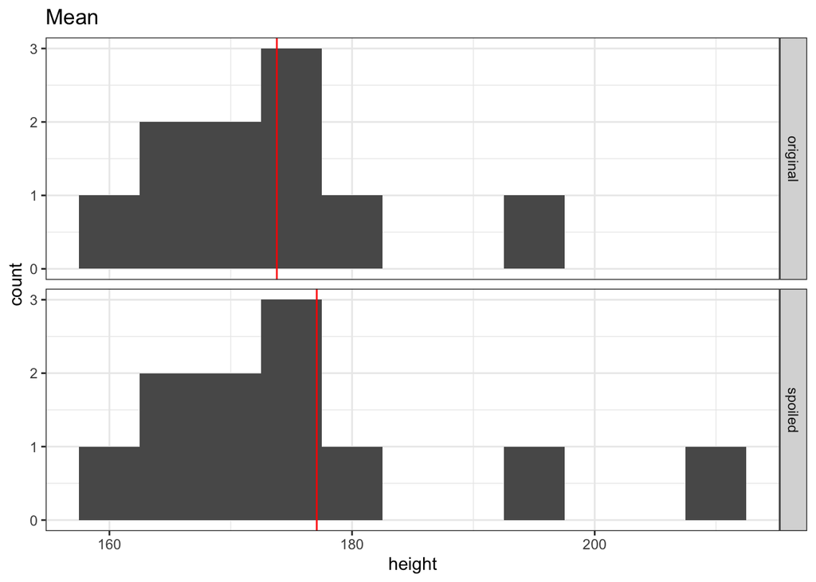

```r
x <- c(175, 176, 182, 165, 167, 172, 175, 196, 158, 172)
x_mean <- mean(x)
x_sp <- c(x, 210)
x_mean_sp <- mean(x_sp)

original <- data.frame(height = x, group = "original")
spoiled <- data.frame(height = x_sp, group = "spoiled")
dataviz <- rbind(original, spoiled)

vline <- data.frame(z = c(x_mean, x_mean_sp), group = c("original", "spoiled"))

ggplot(dataviz, aes(x = height)) +
    geom_histogram(binwidth = 5) +
    geom_vline(aes(xintercept = z), vline, colour = "red")+
    facet_grid(group ~ .) +
    theme_bw() + ggtitle("Mean")
```

#### TASK #1.2 Measures of Spread

- Write your own function or one-liner to calculate variance and sd
- Check the correctness using built-in functions
- Visualize (boxplot) the result for: Q1+Q3, 1-sd borders
- Spoil you data with an outlier and repeat previous step #### Example

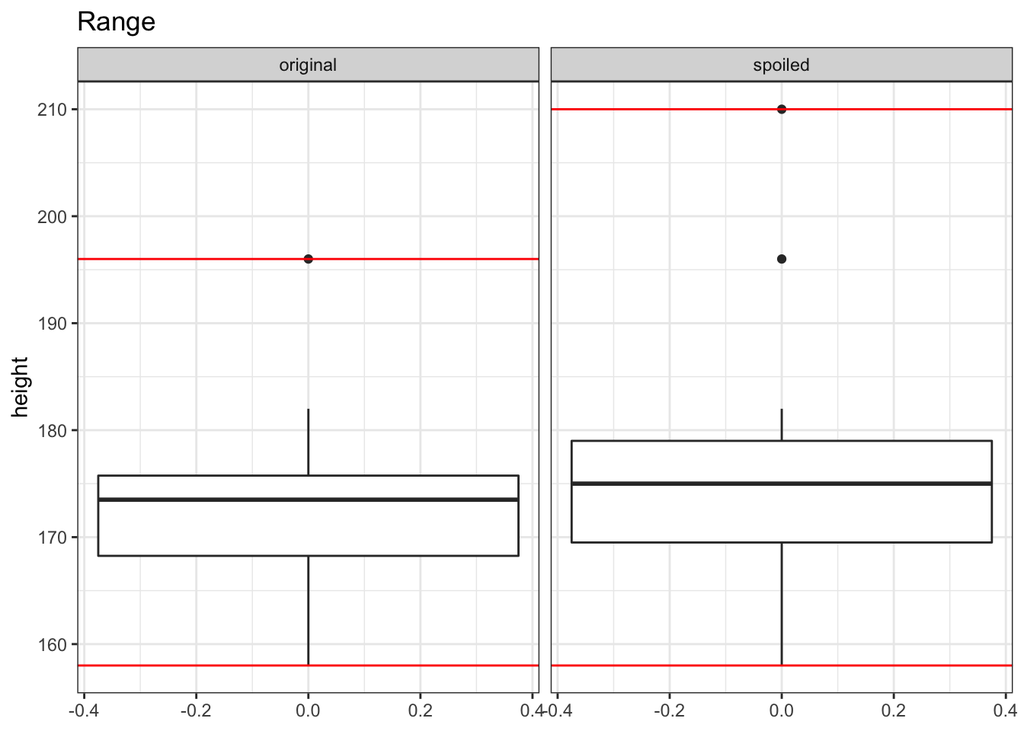

```r
x_range <- range(x)
x_range_sp <- range(x_sp)

hline <- data.frame(z = c(x_range, x_range_sp),
                    group = rep(c("original", "spoiled"), each = 2))

ggplot(dataviz, aes(y = height)) +
    geom_boxplot() +
    geom_hline(aes(yintercept = z), hline, colour = "red")+
    facet_grid(. ~ group) +
    theme_bw() + ggtitle("Range")
```

### Properties

```r
mean(x - 100); mean(x) - 100 # 1
```

```
## [1] 73.8
```

```
## [1] 73.8
```

```r
mean(x / 100); mean(x) / 100 # 2
```

```
## [1] 1.738
```

```
## [1] 1.738
```

```r
sum(x - mean(x)) # 3
```

```
## [1] -1.136868e-13
```

#### Example

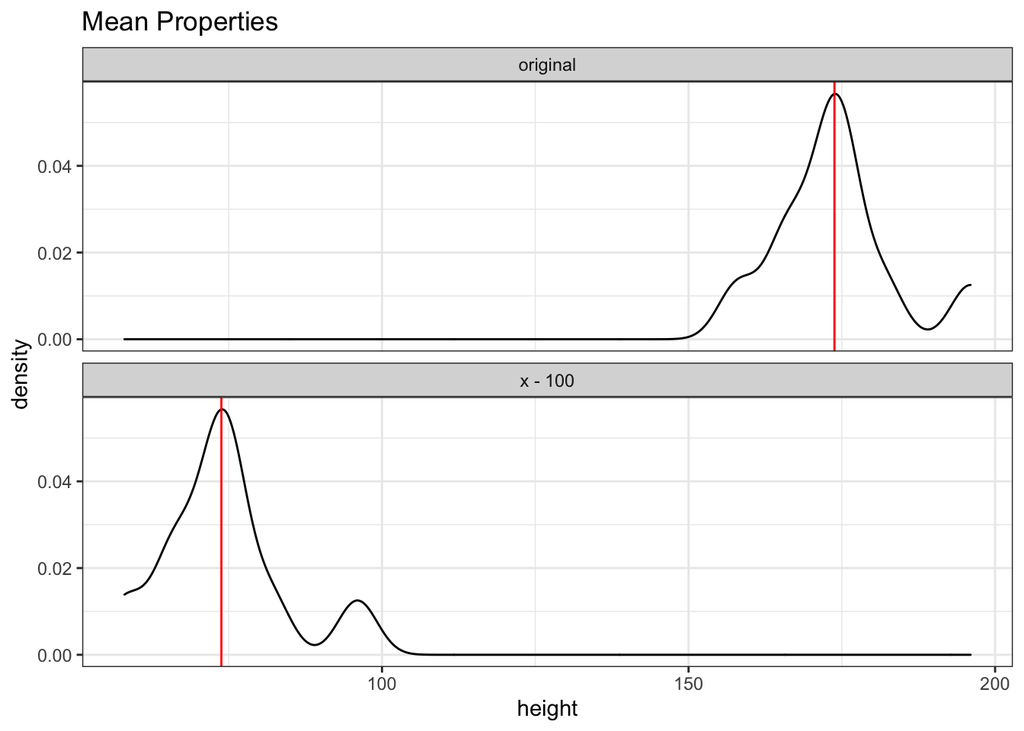

```r
x_ms_100 <- x - 100

original <- data.frame(height = x, group = "original")
trans_ms <- data.frame(height = x_ms_100, group = "x - 100")
dataviz <- rbind(original, trans_ms)

x_ms_mean <- mean(x_ms_100)
vline <- data.frame(z = c(x_mean, x_ms_mean), group = c("original", "x - 100"))

ggplot(dataviz, aes(x = height)) +
    geom_density() +
    geom_vline(aes(xintercept = z), vline, colour = "red")+
    facet_wrap(vars(group), nrow = 2, scales = 'free_y') +
    theme_bw() + ggtitle("Mean Properties")
```

```r
var(x - 100); var(x) # 4
```

```
## [1] 105.2889
```

```
## [1] 105.2889
```

```r
var(x / 100); var(x) / 10000 # 5
```

```
## [1] 0.01052889
```

```
## [1] 0.01052889
```

```r
sd(x / 100); sd(x) / 100 # 6
```

```
## [1] 0.1026104
```

```
## [1] 0.1026104
```

#### TASK #1.3 Properties of Measures

- Check the properties for your sample
- Visualize result tabularly (for # 1-6) and graphically (for # 2 and 6)

### Custom Report

#### TASK #1.4 Statistical Report, part 1

Create descriptive statistics on Pima data set (excluding first and last column) containing information for each column such as: - Number of valid observations (not NA) - Number of missing (NA) values - Mean, Median - Min, max - Q1, Q3 - IQR, SD

Order of columns: - Measure column first, then all the others in free order Order of measures: - As presented below

Values rounded to the 2nd digit

```r
source('utils.R')
numerical_stats(df[, -c(1,9)])
```

```
## # A tibble: 10 x 8
##    Measure   age glucose insulin   mass pedigree pressure triceps
##    <chr>   <dbl>   <dbl>   <dbl>  <dbl>    <dbl>    <dbl>   <dbl>
##  1 N       768     763     394   757      768       733     541
##  2 Missed    0       5     374    11        0        35     227
##  3 Mean     33.2   122.    156.   32.5      0.47     72.4    29.2
##  4 Median   29     117     125    32.3      0.37     72      29
##  5 Min      21      44      14    18.2      0.08     24       7
##  6 Max      81     199     846    67.1      2.42    122      99
##  7 Q1       24      99      76.2  27.5      0.24     64      22
##  8 Q3       41     141     190    36.6      0.63     80      36
##  9 IQR      17      42     114.    9.1      0.38     16      14
## 10 SD       11.8    30.5   119.    6.92     0.33     12.4    10.5
```